# Philemon R Notebook

```r
rm(list=ls())

#Importing libraries
library(MASS)  #Loading Functions for linear and nonlinear modeling (e.g., lda() and qda() for discriminant analysis, glm() for generalized linear models).
library(lars)  #LARS, LASSO, Forward stagewise regression
library(boot)
```

1.a.

```r
#Loading the housing dataset
my_data <- read.csv("/home/kweku/philemon/data visualisation/ML/housing.csv")
```

```r
#read dimension of dataset
dim(my_data)
```

```
[1] 20640    10
```

```r
#read column names
colnames(my_data)
```

```
 [1] "longitude"          "latitude"           "housing_median_age" "total_rooms"        "total_bedrooms"     "population"
 [7] "households"         "median_income"      "median_house_value" "ocean_proximity"
```

```r
#summary statistics
summary(my_data)
```

```
   longitude         latitude     housing_median_age  total_rooms    total_bedrooms     population      households
 Min.   :-124.3   Min.   :32.54   Min.   : 1.00      Min.   :    2   Min.   :   1.0   Min.   :    3   Min.   :   1.0
 1st Qu.:-121.8   1st Qu.:33.93   1st Qu.:18.00      1st Qu.: 1448   1st Qu.: 296.0   1st Qu.:  787   1st Qu.: 280.0
 Median :-118.5   Median :34.26   Median :29.00      Median : 2127   Median : 435.0   Median : 1166   Median : 409.0
 Mean   :-119.6   Mean   :35.63   Mean   :28.64      Mean   : 2636   Mean   : 537.9   Mean   : 1425   Mean   : 499.5
 3rd Qu.:-118.0   3rd Qu.:37.71   3rd Qu.:37.00      3rd Qu.: 3148   3rd Qu.: 647.0   3rd Qu.: 1725   3rd Qu.: 605.0
 Max.   :-114.3   Max.   :41.95   Max.   :52.00      Max.   :39320   Max.   :6445.0   Max.   :35682   Max.   :6082.0
                                                                     NA's   :207
 median_income     median_house_value ocean_proximity
 Min.   : 0.4999   Min.   : 14999     Length:20640
 1st Qu.: 2.5634   1st Qu.:119600     Class :character
 Median : 3.5348   Median :179700     Mode  :character
 Mean   : 3.8707   Mean   :206856
 3rd Qu.: 4.7432   3rd Qu.:264725
 Max.   :15.0001   Max.   :500001
```

```r
#read dataset
head(my_data)
```

|  | longitude | latitude | housing_median_age | total_rooms | total_bedrooms | population | households | median_income | median_house_value | ocean_proximity |
| --- | --- | --- | --- | --- | --- | --- | --- | --- | --- | --- |
| 1 | -122.23 | 37.88 | 41 | 880 | 129 | 322 | 126 | 8.3252 | 452600 | NEAR BAY |
| 2 | -122.22 | 37.86 | 21 | 7099 | 1106 | 2401 | 1138 | 8.3014 | 358500 | NEAR BAY |
| 3 | -122.24 | 37.85 | 52 | 1467 | 190 | 496 | 177 | 7.2574 | 352100 | NEAR BAY |
| 4 | -122.25 | 37.85 | 52 | 1274 | 235 | 558 | 219 | 5.6431 | 341300 | NEAR BAY |
| 5 | -122.25 | 37.85 | 52 | 1627 | 280 | 565 | 259 | 3.8462 | 342200 | NEAR BAY |
| 6 | -122.25 | 37.85 | 52 | 919 | 213 | 413 | 193 | 4.0368 | 269700 | NEAR BAY |

```r
NA
```

```r
#check sum of null values in each column
colSums(is.na(my_data))
```

```
         longitude           latitude housing_median_age        total_rooms     total_bedrooms         population         households
                 0                  0                  0                  0                207                  0                  0
     median_income median_house_value    ocean_proximity
                 0                  0                  0
```

We perform mean imputation to replace the missing values in the total bedrooms column because the data points in the dataset are kept and some not lost by dropping the columns with null. The missing values are replaced by the mean of the column that is total_bedrooms

```r
#mean imputation

#mean of total_bedrooms
mean_bedrooms <- mean(my_data$total_bedrooms, na.rm = TRUE)

#replacing missing values with mean
my_data$total_bedrooms[is.na(my_data$total_bedrooms)] <- mean_bedrooms

#summary statistics
summary(my_data)
```

```
   longitude         latitude     housing_median_age  total_rooms    total_bedrooms     population      households
 Min.   :-124.3   Min.   :32.54   Min.   : 1.00      Min.   :    2   Min.   :   1.0   Min.   :    3   Min.   :   1.0
 1st Qu.:-121.8   1st Qu.:33.93   1st Qu.:18.00      1st Qu.: 1448   1st Qu.: 297.0   1st Qu.:  787   1st Qu.: 280.0
 Median :-118.5   Median :34.26   Median :29.00      Median : 2127   Median : 438.0   Median : 1166   Median : 409.0
 Mean   :-119.6   Mean   :35.63   Mean   :28.64      Mean   : 2636   Mean   : 537.9   Mean   : 1425   Mean   : 499.5
 3rd Qu.:-118.0   3rd Qu.:37.71   3rd Qu.:37.00      3rd Qu.: 3148   3rd Qu.: 643.2   3rd Qu.: 1725   3rd Qu.: 605.0
 Max.   :-114.3   Max.   :41.95   Max.   :52.00      Max.   :39320   Max.   :6445.0   Max.   :35682   Max.   :6082.0
 median_income     median_house_value ocean_proximity
 Min.   : 0.4999   Min.   : 14999     Length:20640
 1st Qu.: 2.5634   1st Qu.:119600     Class :character
 Median : 3.5348   Median :179700     Mode  :character
 Mean   : 3.8707   Mean   :206856
 3rd Qu.: 4.7432   3rd Qu.:264725
 Max.   :15.0001   Max.   :500001
```

1.b. 1. Plotting the scatterplot of median_income and median_house_value

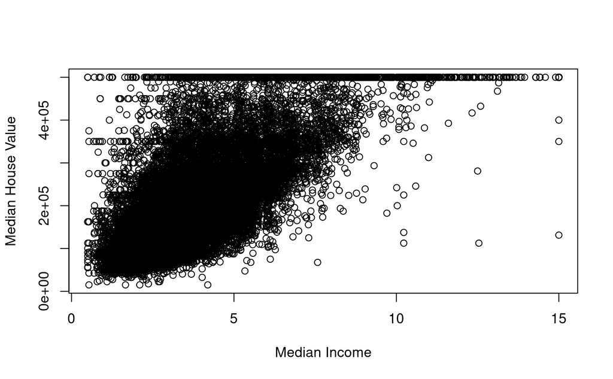

```r
#plot data
plot(my_data$median_income , my_data$median_house_value, xlab = "Median Income" , ylab = "Median House Value")
```

2. Plotting barchart of the values of the ocean_proximity

```r
attach(my_data)

#Check unique values of categorical column
unique(ocean_proximity)
```

```
[1] "NEAR BAY"   "<1H OCEAN"  "INLAND"     "NEAR OCEAN" "ISLAND"
```

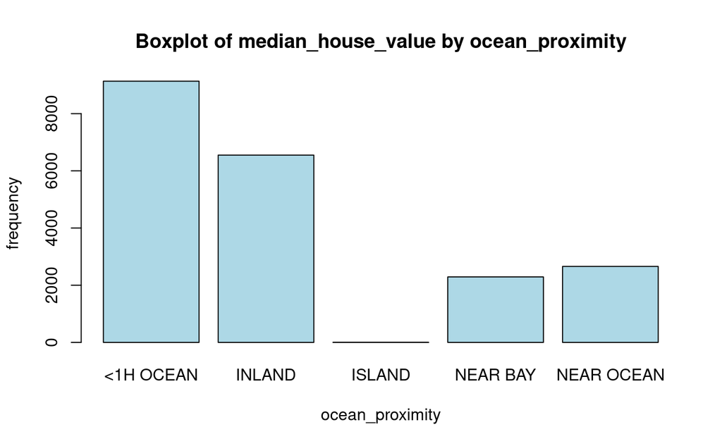

```r
#frequency of each value of ocean_proximity
freq_table <- table(ocean_proximity)

#plotting barplot
barplot(freq_table, main = "Boxplot of median_house_value by ocean_proximity", xlab = "ocean_proximity", ylab = "frequency", col = "lightblue")
```

From the bar chart, most houses less than 1H from the ocean had the highest count with houses on the island having the least count

3.Plotting heatmap to find the correlation between numerical columns

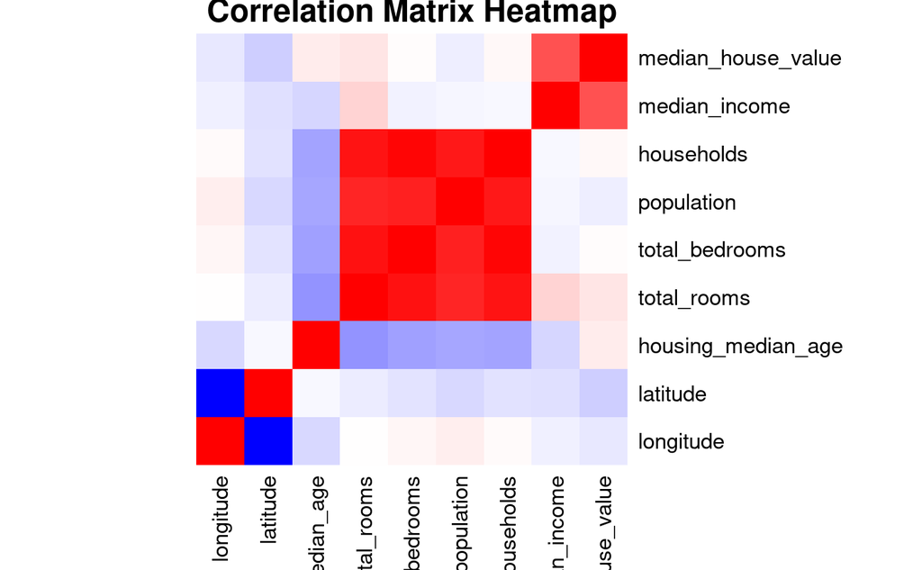

```r
# Select numeric columns
numeric_cols <- my_data[, sapply(my_data, is.numeric)]

# Compute correlation matrix
cor_matrix <- cor(numeric_cols, use = "complete.obs")

#plotting heatmap
heatmap(cor_matrix, Rowv = NA, Colv = NA, col = colorRampPalette(c("blue", "white", "red"))(256), scale = "none", main = "Correlation Matrix Heatmap")
```

```r
# Extract upper triangle, excluding diagonal
upper_tri <- upper.tri(cor_matrix, diag = FALSE)
cor_values <- cor_matrix[upper_tri]
var_pairs <- which(upper_tri, arr.ind = TRUE)
var_names <- data.frame(
  Var1 = rownames(cor_matrix)[var_pairs[, 1]],
  Var2 = colnames(cor_matrix)[var_pairs[, 2]],
  Correlation = cor_values
)

high_cor <- var_names[abs(var_names$Correlation) >= 0.8, ]
print(high_cor)
```

|  | Var1 | Var2 | Correlation |
| --- | --- | --- | --- |
| 1 | longitude | latitude | -0.9246644 |
| 10 | total_rooms | total_bedrooms | 0.9272527 |
| 14 | total_rooms | population | 0.8571260 |
| 15 | total_bedrooms | population | 0.8739095 |
| 19 | total_rooms | households | 0.9184845 |
| 20 | total_bedrooms | households | 0.9747249 |
| 21 | population | households | 0.9072223 |

Two variables that are strongly related to each other (e.g., total_bedrooms and households), it struggles to understand which one primarily affects the target variable (median_house_value). This causes the model’s coefficients to be unstable and difficult to interpret.

1.c. The median_income will have the strongest predictive power for house value based on the correlation matrix

```r
cor_values <- cor_matrix["median_house_value", ]
cor_values <- cor_values[names(cor_values) != "median_house_value"]
cor_df <- data.frame(
  Var1 = "median_house_value",
  Var2 = names(cor_values),
  Correlation = cor_values
)

high_cor <- cor_df[abs(cor_df$Correlation) >= 0.5, ]
print(high_cor)
```

|  | Var1 | Var2 | Correlation |
| --- | --- | --- | --- |
| median_income | median_house_value | median_income | 0.6880752 |

2.a. Fit a simple linear regression model predicting house value using median income. Report the estimated coefficients.

```r
#fitting the simple linear regression
lm.fit=lm(median_house_value~median_income)
lm.fit
```

```
Call:
lm(formula = median_house_value ~ median_income)

Coefficients:
  (Intercept)  median_income
        45086          41794
```

```r
summary(lm.fit)
```

```
Call:
lm(formula = median_house_value ~ median_income)

Residuals:
    Min      1Q  Median      3Q     Max
-540697  -55950  -16979   36978  434023

Coefficients:
              Estimate Std. Error t value Pr(>|t|)
(Intercept)    45085.6     1322.9   34.08   <2e-16 ***
median_income  41793.8      306.8  136.22   <2e-16 ***
---
Signif. codes:  0 ‘***’ 0.001 ‘**’ 0.01 ‘*’ 0.05 ‘.’ 0.1 ‘ ’ 1

Residual standard error: 83740 on 20638 degrees of freedom
Multiple R-squared:  0.4734,    Adjusted R-squared:  0.4734
F-statistic: 1.856e+04 on 1 and 20638 DF,  p-value: < 2.2e-16
```

```r
coef(lm.fit)
```

```
  (Intercept) median_income
     45085.58      41793.85
```

```r
confint(lm.fit)
```

```
                 2.5 %   97.5 %
(Intercept)   42492.64 47678.51
median_income 41192.49 42395.21
```

```r
r_squared_slr <- summary(lm.fit)$r.squared
adj_rsquared_slr <- summary(lm.fit)$adj.r.squared
```

R-squared = 0.4734: median income alone explains about 47% of the variation in median house value outcomes. The remaining 53% is due to other predictors or random error.

2.b. Intercept = 45085.58: represents that when the median income is 0. Slope = 41793.85 : represents that for every one unit increase in the median income, the median house value increases on average about 41793 points.

2.c.

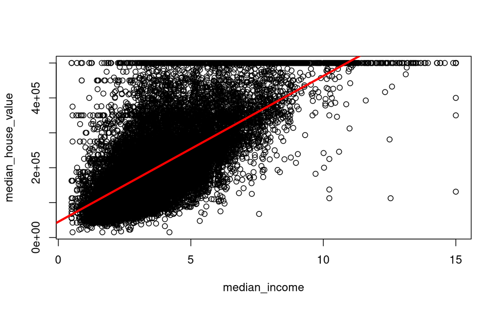

```r
#plot median income and median house value
plot(median_income,median_house_value)

#regression line
abline(lm.fit , lwd = 3, col = "red")
```

The regression line which is a positive slope and most of the data points clustered around the slope indicates a strong relationship betweeen the median income and median house value.

3.a. Fit a multiple regression model using all available predictors. Report the regression summary.

```r
#Fit a multiple regression model using all available predictors
lm.fit=lm(median_house_value~longitude + latitude + housing_median_age + total_rooms + total_bedrooms + population + households + median_income + ocean_proximity)
lm.fit
```

```
Call:
lm(formula = median_house_value ~ longitude + latitude + housing_median_age +
    total_rooms + total_bedrooms + population + households +
    median_income + ocean_proximity)

Coefficients:
              (Intercept)                  longitude                   latitude         housing_median_age                total_rooms
               -2.236e+06                 -2.646e+04                 -2.520e+04                  1.058e+03                 -4.773e+00
           total_bedrooms                 population                 households              median_income      ocean_proximityINLAND
                7.229e+01                 -3.926e+01                  7.694e+01                  3.877e+04                 -3.972e+04
    ocean_proximityISLAND    ocean_proximityNEAR BAY  ocean_proximityNEAR OCEAN
                1.560e+05                 -3.690e+03                  4.747e+03
```

```r
coef(lm.fit)
```

```
              (Intercept)                 longitude                  latitude        housing_median_age               total_rooms
            -2.235717e+06             -2.645829e+04             -2.519720e+04              1.057864e+03             -4.772530e+00
           total_bedrooms                population                households             median_income     ocean_proximityINLAND
             7.228959e+01             -3.926184e+01              7.694086e+01              3.877491e+04             -3.971968e+04
    ocean_proximityISLAND   ocean_proximityNEAR BAY ocean_proximityNEAR OCEAN
             1.560420e+05             -3.689751e+03              4.747402e+03
```

```r
summary(lm.fit)
```

```
Call:
lm(formula = median_house_value ~ longitude + latitude + housing_median_age +
    total_rooms + total_bedrooms + population + households +
    median_income + ocean_proximity)

Residuals:
    Min      1Q  Median      3Q     Max
-550704  -42710  -10626   28722  794741

Coefficients:
                            Estimate Std. Error t value Pr(>|t|)
(Intercept)               -2.236e+06  8.750e+04 -25.552  < 2e-16 ***
longitude                 -2.646e+04  1.014e+03 -26.092  < 2e-16 ***
latitude                  -2.520e+04  9.999e+02 -25.200  < 2e-16 ***
housing_median_age         1.058e+03  4.370e+01  24.205  < 2e-16 ***
total_rooms               -4.772e+00  7.715e-01  -6.186 6.29e-10 ***
total_bedrooms             7.229e+01  5.984e+00  12.080  < 2e-16 ***
population                -3.926e+01  1.064e+00 -36.896  < 2e-16 ***
households                 7.694e+01  6.696e+00  11.490  < 2e-16 ***
median_income              3.877e+04  3.324e+02 116.635  < 2e-16 ***
ocean_proximityINLAND     -3.972e+04  1.736e+03 -22.875  < 2e-16 ***
ocean_proximityISLAND      1.560e+05  3.077e+04   5.071 3.99e-07 ***
ocean_proximityNEAR BAY   -3.690e+03  1.906e+03  -1.936  0.05289 .
ocean_proximityNEAR OCEAN  4.747e+03  1.563e+03   3.038  0.00238 **
---
Signif. codes:  0 ‘***’ 0.001 ‘**’ 0.01 ‘*’ 0.05 ‘.’ 0.1 ‘ ’ 1

Residual standard error: 68730 on 20627 degrees of freedom
Multiple R-squared:  0.6455,    Adjusted R-squared:  0.6453
F-statistic:  3130 on 12 and 20627 DF,  p-value: < 2.2e-16
```

```r
round(summary(lm.fit)$coefficients,5)
```

```
                               Estimate  Std. Error   t value Pr(>|t|)
(Intercept)               -2.235717e+06 87495.11654 -25.55248  0.00000
longitude                 -2.645829e+04  1014.03500 -26.09209  0.00000
latitude                  -2.519720e+04   999.90777 -25.19952  0.00000
housing_median_age         1.057864e+03    43.70431  24.20502  0.00000
total_rooms               -4.772530e+00     0.77150  -6.18603  0.00000
total_bedrooms             7.228959e+01     5.98411  12.08026  0.00000
population                -3.926184e+01     1.06411 -36.89630  0.00000
households                 7.694086e+01     6.69618  11.49027  0.00000
median_income              3.877491e+04   332.44655 116.63503  0.00000
ocean_proximityINLAND     -3.971968e+04  1736.41177 -22.87457  0.00000
ocean_proximityISLAND      1.560420e+05 30771.52889   5.07099  0.00000
ocean_proximityNEAR BAY   -3.689751e+03  1905.95976  -1.93590  0.05289
ocean_proximityNEAR OCEAN  4.747402e+03  1562.68832   3.03797  0.00238
```

```r
confint(lm.fit)
```

```
                                  2.5 %        97.5 %
(Intercept)               -2.407214e+06 -2.064220e+06
longitude                 -2.844588e+04 -2.447070e+04
latitude                  -2.715710e+04 -2.323730e+04
housing_median_age         9.721999e+02  1.143528e+03
total_rooms               -6.284734e+00 -3.260326e+00
total_bedrooms             6.056027e+01  8.401891e+01
population                -4.134759e+01 -3.717610e+01
households                 6.381583e+01  9.006589e+01
median_income              3.812329e+04  3.942654e+04
ocean_proximityINLAND     -4.312318e+04 -3.631617e+04
ocean_proximityISLAND      9.572734e+04  2.163566e+05
ocean_proximityNEAR BAY   -7.425582e+03  4.608101e+01
ocean_proximityNEAR OCEAN  1.684410e+03  7.810395e+03
```

```r
r_squared_mlr <- summary(lm.fit)$r.squared
adj_rsquared_mlr <- summary(lm.fit)$adj.r.squared
```

R squared ≈ 0.64: Together, the predictors explain about 64% of the variation in median house value outcomes, substantially better than median income alone.

3.c. comparison between simple regression model and multiple regression model using Rsquared and Adjusted R squared

```r
r_compare <- data.frame(par = c("R-squared","Adjusted R-squared"),slr = c(r_squared_slr,adj_rsquared_slr), mlr = c(r_squared_mlr,adj_rsquared_mlr))

r_compare
```

| par | slr | mlr |
| --- | --- | --- |
| R-squared | 0.4734475 | 0.6454748 |
| Adjusted R-squared | 0.4734220 | 0.6452685 |

Conclusion: The multiple regression model is likely better if the Adjusted R squared is significantly higher, as it balances fit and complexity.

3.d.

```r
high_cor <- var_names[abs(var_names$Correlation) >= 0.8, ]

print(high_cor)
```

|  | Var1 | Var2 | Correlation |
| --- | --- | --- | --- |
| 1 | longitude | latitude | -0.9246644 |
| 10 | total_rooms | total_bedrooms | 0.9272527 |
| 14 | total_rooms | population | 0.8571260 |
| 15 | total_bedrooms | population | 0.8739095 |
| 19 | total_rooms | households | 0.9184845 |
| 20 | total_bedrooms | households | 0.9747249 |
| 21 | population | households | 0.9072223 |

4.a. Using median income as the sole predictor, fit polynomial regression models of degree 1, 2, 3, and 4.

```r
#polynomial = 1
lm.fit=lm(median_house_value~poly(median_income,1))
lm.fit
```

```
Call:
lm(formula = median_house_value ~ poly(median_income, 1))

Coefficients:
           (Intercept)  poly(median_income, 1)
                206856                11406950
```

```r
summary(lm.fit)
```

```
Call:
lm(formula = median_house_value ~ poly(median_income, 1))

Residuals:
    Min      1Q  Median      3Q     Max
-540697  -55950  -16979   36978  434023

Coefficients:
                        Estimate Std. Error t value Pr(>|t|)
(Intercept)            2.069e+05  5.829e+02   354.9   <2e-16 ***
poly(median_income, 1) 1.141e+07  8.374e+04   136.2   <2e-16 ***
---
Signif. codes:  0 ‘***’ 0.001 ‘**’ 0.01 ‘*’ 0.05 ‘.’ 0.1 ‘ ’ 1

Residual standard error: 83740 on 20638 degrees of freedom
Multiple R-squared:  0.4734,    Adjusted R-squared:  0.4734
F-statistic: 1.856e+04 on 1 and 20638 DF,  p-value: < 2.2e-16
```

```r
coef(lm.fit)
```

```
           (Intercept) poly(median_income, 1)
              206855.8             11406950.2
```

```r
confint(lm.fit)
```

```
                            2.5 %     97.5 %
(Intercept)              205713.4   207998.3
poly(median_income, 1) 11242817.8 11571082.6
```

```r
#polynomial = 2
lm.fit=lm(median_house_value~poly(median_income,2))
lm.fit
```

```
Call:
lm(formula = median_house_value ~ poly(median_income, 2))

Coefficients:
            (Intercept)  poly(median_income, 2)1  poly(median_income, 2)2
                 206856                 11406950                 -1121508
```

```r
summary(lm.fit)
```

```
Call:
lm(formula = median_house_value ~ poly(median_income, 2))

Residuals:
    Min      1Q  Median      3Q     Max
-450948  -55535  -16549   37400  453242

Coefficients:
                          Estimate Std. Error t value Pr(>|t|)
(Intercept)               206855.8      580.3  356.44   <2e-16 ***
poly(median_income, 2)1 11406950.2    83375.0  136.81   <2e-16 ***
poly(median_income, 2)2 -1121508.0    83375.0  -13.45   <2e-16 ***
---
Signif. codes:  0 ‘***’ 0.001 ‘**’ 0.01 ‘*’ 0.05 ‘.’ 0.1 ‘ ’ 1

Residual standard error: 83370 on 20637 degrees of freedom
Multiple R-squared:  0.478, Adjusted R-squared:  0.478
F-statistic:  9450 on 2 and 20637 DF,  p-value: < 2.2e-16
```

```r
coef(lm.fit)
```

```
            (Intercept) poly(median_income, 2)1 poly(median_income, 2)2
               206855.8              11406950.2              -1121508.0
```

```r
confint(lm.fit)
```

```
                             2.5 %     97.5 %
(Intercept)               205718.3   207993.3
poly(median_income, 2)1 11243528.7 11570371.7
poly(median_income, 2)2 -1284929.5  -958086.5
```

```r
#polynomial = 3
lm.fit=lm(median_house_value~poly(median_income,3))
lm.fit
```

```
Call:
lm(formula = median_house_value ~ poly(median_income, 3))

Coefficients:
            (Intercept)  poly(median_income, 3)1  poly(median_income, 3)2  poly(median_income, 3)3
                 206856                 11406950                 -1121508                 -1498578
```

```r
summary(lm.fit)
```

```
Call:
lm(formula = median_house_value ~ poly(median_income, 3))

Residuals:
    Min      1Q  Median      3Q     Max
-406137  -55850  -16639   36074  414234

Coefficients:
                          Estimate Std. Error t value Pr(>|t|)
(Intercept)               206855.8      575.8  359.25   <2e-16 ***
poly(median_income, 3)1 11406950.2    82721.8  137.90   <2e-16 ***
poly(median_income, 3)2 -1121508.0    82721.8  -13.56   <2e-16 ***
poly(median_income, 3)3 -1498577.8    82721.8  -18.12   <2e-16 ***
---
Signif. codes:  0 ‘***’ 0.001 ‘**’ 0.01 ‘*’ 0.05 ‘.’ 0.1 ‘ ’ 1

Residual standard error: 82720 on 20636 degrees of freedom
Multiple R-squared:  0.4862,    Adjusted R-squared:  0.4861
F-statistic:  6509 on 3 and 20636 DF,  p-value: < 2.2e-16
```

```r
coef(lm.fit)
```

```
            (Intercept) poly(median_income, 3)1 poly(median_income, 3)2 poly(median_income, 3)3
               206855.8              11406950.2              -1121508.0              -1498577.8
```

```r
confint(lm.fit)
```

```
                             2.5 %     97.5 %
(Intercept)               205727.2   207984.4
poly(median_income, 3)1 11244809.0 11569091.4
poly(median_income, 3)2 -1283649.3  -959366.8
poly(median_income, 3)3 -1660719.1 -1336436.6
```

```r
#polynomial = 4
lm.fit=lm(median_house_value~poly(median_income,4))
lm.fit
```

```
Call:
lm(formula = median_house_value ~ poly(median_income, 4))

Coefficients:
            (Intercept)  poly(median_income, 4)1  poly(median_income, 4)2  poly(median_income, 4)3  poly(median_income, 4)4
                 206856                 11406950                 -1121508                 -1498578                   175301
```

```r
summary(lm.fit)
```

```
Call:
lm(formula = median_house_value ~ poly(median_income, 4))

Residuals:
    Min      1Q  Median      3Q     Max
-398752  -55982  -16545   35865  407836

Coefficients:
                          Estimate Std. Error t value Pr(>|t|)
(Intercept)               206855.8      575.7 359.285   <2e-16 ***
poly(median_income, 4)1 11406950.2    82714.8 137.907   <2e-16 ***
poly(median_income, 4)2 -1121508.0    82714.8 -13.559   <2e-16 ***
poly(median_income, 4)3 -1498577.8    82714.8 -18.117   <2e-16 ***
poly(median_income, 4)4   175300.7    82714.8   2.119   0.0341 *
---
Signif. codes:  0 ‘***’ 0.001 ‘**’ 0.01 ‘*’ 0.05 ‘.’ 0.1 ‘ ’ 1

Residual standard error: 82710 on 20635 degrees of freedom
Multiple R-squared:  0.4863,    Adjusted R-squared:  0.4862
F-statistic:  4884 on 4 and 20635 DF,  p-value: < 2.2e-16
```

```r
coef(lm.fit)
```

```
            (Intercept) poly(median_income, 4)1 poly(median_income, 4)2 poly(median_income, 4)3 poly(median_income, 4)4
               206855.8              11406950.2              -1121508.0              -1498577.8                175300.7
```

```r
confint(lm.fit)
```

```
                              2.5 %     97.5 %
(Intercept)               205727.32   207984.3
poly(median_income, 4)1 11244822.67 11569077.7
poly(median_income, 4)2 -1283635.54  -959380.5
poly(median_income, 4)3 -1660705.35 -1336450.3
poly(median_income, 4)4    13173.22   337428.2
```

4.b. # This function estimates the train and test errors for simple regressions with polynomials of deg=1:4 # for a given seed, and returns these values in a 2x4 matrix

```r
myfn <- function(xx,yy,seed){
    set.seed(seed)
    train=sample(length(yy),length(yy)/2)
    out=matrix(,2,4)

    for(j in 1:4){
        fit=lm(yy~poly(xx,j),subset=train)
        out[1,j]=mean(fit$residuals^2)              #training error
        newdata <- data.frame(xx = xx)
        out[2,j]=mean((yy-predict(fit,newdata = newdata))[-train]^2)    #test error
    }

    return(out)
}

err.1 = myfn(median_income,median_house_value,1)
err.2 = myfn(median_income,median_house_value,2)

err.1
```

```
           [,1]       [,2]       [,3]       [,4]
[1,] 6883505273 6808252606 6703841819 6702903309
[2,] 7139167631 7093696314 6980286369 6978387394
```

```r
err.2
```

```
           [,1]       [,2]       [,3]       [,4]
[1,] 6911843925 6862271319 6768602874 6768466292
[2,] 7112434510 7040273329 6916029498 6914597596
```

4.c.

```r
# Prepare data
degrees <- 1:4
train_error <- err.1[1, ]
test_error <- err.1[2, ]

# Plot
plot(degrees, train_error, type = "b", col = "blue", pch = 16,
     ylim = range(c(train_error, test_error)),
     xlab = "Polynomial Degree", ylab = "Mean Squared Error",
     main = "Training vs Test Error Across Polynomial Degrees")
lines(degrees, test_error, type = "b", col = "red", pch = 17)
```

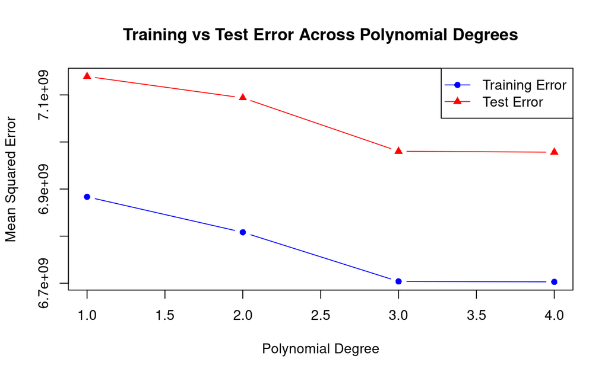

```r
legend("topright", legend = c("Training Error", "Test Error"),
       col = c("blue", "red"), pch = c(16, 17), lty = 1)
```

```r
# Prepare data
degrees <- 1:4
train_error <- err.2[1, ]
test_error <- err.2[2, ]

# Plot
plot(degrees, train_error, type = "b", col = "blue", pch = 16,
     ylim = range(c(train_error, test_error)),
     xlab = "Polynomial Degree", ylab = "Mean Squared Error",
     main = "Training vs Test Error Across Polynomial Degrees")
lines(degrees, test_error, type = "b", col = "red", pch = 17)
```

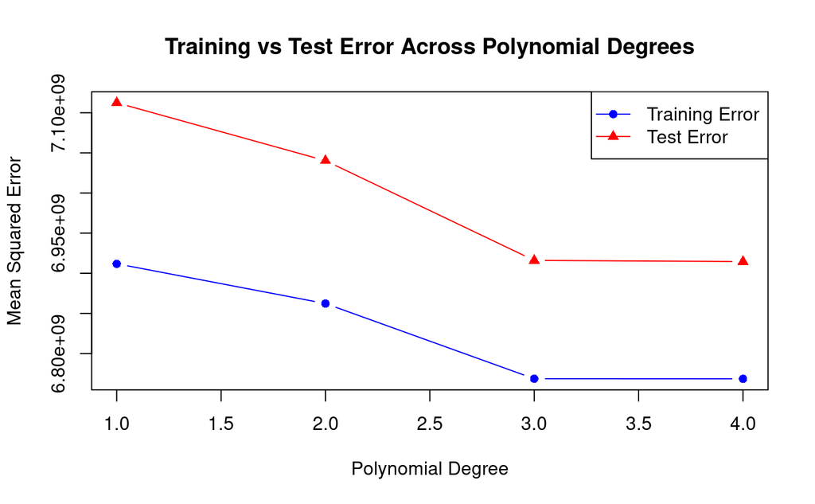

```r
legend("topright", legend = c("Training Error", "Test Error"),
       col = c("blue", "red"), pch = c(16, 17), lty = 1)
```

5.a. 10-fold cross-validation to estimate prediction error for models of degree 1-5

```r
dat=data.frame(median_income,median_house_value)
set.seed(5)
cv.error.5=numeric(5)
train.err.5=numeric(5)
for (i in 1:5){
 glm.fit=glm(median_house_value~poly(median_income,i),data=dat)
 cv.error.5[i]=cv.glm(dat,glm.fit,K=10)$delta[1]
 train.err.5[i]=mean(glm.fit$residuals^2)
 }
cv.error.5
```

```
[1] 7013808328 6952274798 6842721744 6842924581 6843373514
```

5.b. Repeat the cross-validation 50 times and present the distribution of errors using boxplots

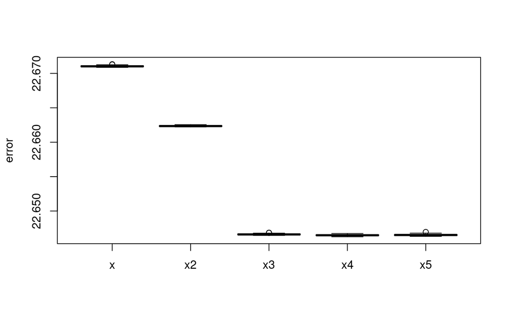

```r
dat=data.frame(median_income,median_house_value)
cv.error.50 = matrix(,50,5)
for (i in 1:50){
    set.seed(i)
  for (k in 1:5) {
    glm.fit=glm(median_house_value~poly(median_income,k),data=dat)
    cv.error.50[i,k]=cv.glm(dat,glm.fit,K=10)$delta[1]
  }
 }

boxplot(log(cv.error.50), col=c(4,2), names=c('x','x2','x3','x4','x5'), ylab='error')
```

6.a Regression plays a foundational role in real-world predictive modeling by providing a structured framework to understand and quantify relationships between variables. In practice, regression techniques, such as linear, logistic, or more advanced variants like ridge or lasso, allow modelers to predict outcomes based on input features, estimating how changes in predictors influence the target variable.

Error analysis is crucial for assessing and improving model performance in predictive modeling, serving as a diagnostic tool to understand where and why predictions fail. By examining metrics like mean squared error (MSE), mean absolute error (MAE), or confusion matrices, analysts can identify patterns in residuals or misclassifications, such as bias toward certain data subsets or sensitivity to outliers.

Cross-validation complements regression and error analysis by providing a robust method to evaluate model generalization, mitigating risks of overfitting in real-world scenarios. Techniques like k-fold cross-validation divide the data into training and validation sets multiple times, averaging performance metrics to estimate how the model will perform on unseen data.

6.b. I will choose the model with cross validation which complements regression and error analysis by providing a robust method to evaluate model generalization, mitigating risks of overfitting.